# Project1

Mehreen Ali Gillani

2025-09-20

# Topic: Chess Tournament Performance Analysis

## Approach:

- Created structured player data with round-by-round results (W/L/D) and opponent matchups
- Calculated total points from game outcomes and average opponent ratings
- Generated visualizations to compare player performance against pre-tournament ratings
- Analyzed discrepancies between expected and actual performance based on rating tiers

### Step 1: Load Required Libraries

```r
library(dplyr)
```

```r
library(tidyr)
library(stringr)
library(ggplot2)
library(forcats)
library(kableExtra)
```

### Step 2: Create Sample Data with Round Results and opponents

```r
players_data <- data.frame(
  Player = c("Gary Hua", "Alice Smith", "Bob Johnson", "Charlie Brown", "Diana Davis"),
  State = c("ON", "CA", "TX", "NY", "FL"),
  PreRating = c(1794, 1650, 1550, 1700, 1600),
  R1_Result = c("W", "L", "D", "W", "L"),
  R1_Opponent = c("Alice Smith", "Gary Hua", "Charlie Brown", "Bob Johnson", "Diana Davis"),
  R2_Result = c("W", "W", "L", "D", "W"),
  R2_Opponent = c("Bob Johnson", "Charlie Brown", "Gary Hua", "Alice Smith", "Diana Davis"),
  R3_Result = c("D", "W", "W", "L", "L"),
  R3_Opponent = c("Charlie Brown", "Diana Davis", "Alice Smith", "Gary Hua", "Bob Johnson"),
  R4_Result = c("W", "D", "L", "W", "D"),
  R4_Opponent = c("Diana Davis", "Bob Johnson", "Alice Smith", "Diana Davis", "Gary Hua"),
  R5_Result = c("W", "W", "D", "L", "W"),
  R5_Opponent = c("Charlie Brown", "Diana Davis", "Bob Johnson", "Alice Smith", "Charlie Brown"),
  OpponentRatings = c(
    "1650, 1550, 1700, 1600, 1700",
    "1794, 1700, 1600, 1550, 1600",
    "1794, 1794, 1650, 1650, 1550",
    "1550, 1650, 1794, 1600, 1650",
    "1600, 1600, 1550, 1794, 1700"
  )
)

# Display the data

players_data %>%
  kable(format = "html", escape = FALSE) %>%  # Ensure HTML format and escape special characters if needed
  kable_styling(
    bootstrap_options = c("bordered", "striped", "condensed"),  # Add borders, striped rows, and compact spacing
    position = "center", # Center the table on the page :cite[1]
    font_size = 12,      # Adjust font size for better readability
  )# %>%
```

| Player | State | PreRating | R1_Result | R1_Opponent | R2_Result | R2_Opponent | R3_Result | R3_Opponent | R4_Result | R4_Opponent | R5_Result | R5_Opponent | OpponentRatings |
| --- | --- | --- | --- | --- | --- | --- | --- | --- | --- | --- | --- | --- | --- |
| Gary Hua | ON | 1794 | W | Alice Smith | W | Bob Johnson | D | Charlie Brown | W | Diana Davis | W | Charlie Brown | 1650, 1550, 1700, 1600, 1700 |
| Alice Smith | CA | 1650 | L | Gary Hua | W | Charlie Brown | W | Diana Davis | D | Bob Johnson | W | Diana Davis | 1794, 1700, 1600, 1550, 1600 |
| Bob Johnson | TX | 1550 | D | Charlie Brown | L | Gary Hua | W | Alice Smith | L | Alice Smith | D | Bob Johnson | 1794, 1794, 1650, 1650, 1550 |
| Charlie Brown | NY | 1700 | W | Bob Johnson | D | Alice Smith | L | Gary Hua | W | Diana Davis | L | Alice Smith | 1550, 1650, 1794, 1600, 1650 |
| Diana Davis | FL | 1600 | L | Diana Davis | W | Diana Davis | L | Bob Johnson | D | Gary Hua | W | Charlie Brown | 1600, 1600, 1550, 1794, 1700 |

```r
 # row_spec(0, bold = TRUE, background = "#f8f9fa")  # Style header row: bold text and light background
```

### Step 3: Calculate Total Points from Round Results:

for each W=win pt=1, for each D=Draw pt=0.5, for each L=Lost pt=0 aded in this list

```r
processed_data <- players_data %>%
  mutate(
    TotalPoints = (
      (R1_Result == "W") + (R2_Result == "W") + (R3_Result == "W") +
      (R4_Result == "W") + (R5_Result == "W") +
      (R1_Result == "D")*0.5 + (R2_Result == "D")*0.5 +
      (R3_Result == "D")*0.5 + (R4_Result == "D")*0.5 +
      (R5_Result == "D")*0.5
    )
  )
# Display the data with calculated points
processed_data %>%
  kable(format = "html", escape = FALSE) %>%  # Ensure HTML format and escape special characters if needed
  kable_styling(
    bootstrap_options = c("bordered", "striped", "condensed"),  # Add borders, striped rows, and compact spacing
    position = "center", # Center the table on the page :cite[1]
    font_size = 12,      # Adjust font size for better readability
  )
```

| Player | State | PreRating | R1_Result | R1_Opponent | R2_Result | R2_Opponent | R3_Result | R3_Opponent | R4_Result | R4_Opponent | R5_Result | R5_Opponent | OpponentRatings | TotalPoints |
| --- | --- | --- | --- | --- | --- | --- | --- | --- | --- | --- | --- | --- | --- | --- |
| Gary Hua | ON | 1794 | W | Alice Smith | W | Bob Johnson | D | Charlie Brown | W | Diana Davis | W | Charlie Brown | 1650, 1550, 1700, 1600, 1700 | 4.5 |
| Alice Smith | CA | 1650 | L | Gary Hua | W | Charlie Brown | W | Diana Davis | D | Bob Johnson | W | Diana Davis | 1794, 1700, 1600, 1550, 1600 | 3.5 |
| Bob Johnson | TX | 1550 | D | Charlie Brown | L | Gary Hua | W | Alice Smith | L | Alice Smith | D | Bob Johnson | 1794, 1794, 1650, 1650, 1550 | 2.0 |
| Charlie Brown | NY | 1700 | W | Bob Johnson | D | Alice Smith | L | Gary Hua | W | Diana Davis | L | Alice Smith | 1550, 1650, 1794, 1600, 1650 | 2.5 |
| Diana Davis | FL | 1600 | L | Diana Davis | W | Diana Davis | L | Bob Johnson | D | Gary Hua | W | Charlie Brown | 1600, 1600, 1550, 1794, 1700 | 2.5 |

### Step 4: Calculate Average Opponent Rating:

AvgOpponentRating=sum(OpponentRatings)/total_number_of_rounds

```r
processed_data <- processed_data %>%
  rowwise() %>%
  mutate(
    OpponentList = strsplit(OpponentRatings, ","),
    AvgOpponentRating = mean(as.numeric(trimws(OpponentList)), na.rm = TRUE)
  )

# Display the data with average opponent rating
processed_data_display <- processed_data  %>%
select(Player, State, PreRating, TotalPoints, OpponentList, AvgOpponentRating)

processed_data_display %>%
  kable(format = "html", escape = FALSE) %>%  # Ensure HTML format and escape special characters if needed
  kable_styling(
    bootstrap_options = c("bordered", "striped", "condensed"),  # Add borders, striped rows, and compact spacing
    position = "center", # Center the table on the page :cite[1]
    font_size = 12,      # Adjust font size for better readability
  )
```

| Player | State | PreRating | TotalPoints | OpponentList | AvgOpponentRating |
| --- | --- | --- | --- | --- | --- |
| Gary Hua | ON | 1794 | 4.5 | 1650 , 1550, 1700, 1600, 1700 | 1640.0 |
| Alice Smith | CA | 1650 | 3.5 | 1794 , 1700, 1600, 1550, 1600 | 1648.8 |
| Bob Johnson | TX | 1550 | 2.0 | 1794 , 1794, 1650, 1650, 1550 | 1687.6 |
| Charlie Brown | NY | 1700 | 2.5 | 1550 , 1650, 1794, 1600, 1650 | 1648.8 |
| Diana Davis | FL | 1600 | 2.5 | 1600 , 1600, 1550, 1794, 1700 | 1648.8 |

### Step 5: Select Final Columns and Save to CSV

```r
final_data <- processed_data %>%
  select(Player, State, TotalPoints, PreRating, AvgOpponentRating,
         R1_Result, R1_Opponent, R2_Result, R2_Opponent,
         R3_Result, R3_Opponent, R4_Result, R4_Opponent,
         R5_Result, R5_Opponent)

# Save as CSV
write.csv(final_data, "player_stats_with_rounds_and_opponents.csv", row.names = FALSE)
```

### Step 6: Read and Verify the CSV File

```r
# Read the CSV file to verify it was saved correctly
saved_data <- read.csv("player_stats_with_rounds_and_opponents.csv")
```

### Step 7: Create a Summary of Results by Player

```r
player_summary <- saved_data %>%
  select(Player, State, PreRating, TotalPoints, AvgOpponentRating)

# Display player summary
player_summary %>%
  kable(format = "html", escape = FALSE) %>%  # Ensure HTML format and escape special characters if needed
  kable_styling(
    bootstrap_options = c("bordered", "striped", "condensed"),  # Add borders, striped rows, and compact spacing
    position = "center", # Center the table on the page :cite[1]
    font_size = 12,      # Adjust font size for better readability
  )
```

| Player | State | PreRating | TotalPoints | AvgOpponentRating |
| --- | --- | --- | --- | --- |
| Gary Hua | ON | 1794 | 4.5 | 1640.0 |
| Alice Smith | CA | 1650 | 3.5 | 1648.8 |
| Bob Johnson | TX | 1550 | 2.0 | 1687.6 |
| Charlie Brown | NY | 1700 | 2.5 | 1648.8 |
| Diana Davis | FL | 1600 | 2.5 | 1648.8 |

### Step 8: Create a Detailed Round-by-Round View

```r
# Create a detailed round-by-round view
round_details <- saved_data %>%
  select(Player, starts_with("R")) %>%
  pivot_longer(
    cols = -Player,
    names_to = c("Round", ".value"),
    names_sep = "_"
  ) %>%
  arrange(Player, Round)

# Display round details
round_details %>%
  kable(format = "html", escape = FALSE) %>%  # Ensure HTML format and escape special characters if needed
  kable_styling(
    bootstrap_options = c("bordered", "striped", "condensed"),  # Add borders, striped rows, and compact spacing
    position = "center", # Center the table on the page :cite[1]
    font_size = 12,      # Adjust font size for better readability
  )
```

| Player | Round | Result | Opponent |
| --- | --- | --- | --- |
| Alice Smith | R1 | L | Gary Hua |
| Alice Smith | R2 | W | Charlie Brown |
| Alice Smith | R3 | W | Diana Davis |
| Alice Smith | R4 | D | Bob Johnson |
| Alice Smith | R5 | W | Diana Davis |
| Bob Johnson | R1 | D | Charlie Brown |
| Bob Johnson | R2 | L | Gary Hua |
| Bob Johnson | R3 | W | Alice Smith |
| Bob Johnson | R4 | L | Alice Smith |
| Bob Johnson | R5 | D | Bob Johnson |
| Charlie Brown | R1 | W | Bob Johnson |
| Charlie Brown | R2 | D | Alice Smith |
| Charlie Brown | R3 | L | Gary Hua |
| Charlie Brown | R4 | W | Diana Davis |
| Charlie Brown | R5 | L | Alice Smith |
| Diana Davis | R1 | L | Diana Davis |
| Diana Davis | R2 | W | Diana Davis |
| Diana Davis | R3 | L | Bob Johnson |
| Diana Davis | R4 | D | Gary Hua |
| Diana Davis | R5 | W | Charlie Brown |
| Gary Hua | R1 | W | Alice Smith |
| Gary Hua | R2 | W | Bob Johnson |
| Gary Hua | R3 | D | Charlie Brown |
| Gary Hua | R4 | W | Diana Davis |
| Gary Hua | R5 | W | Charlie Brown |

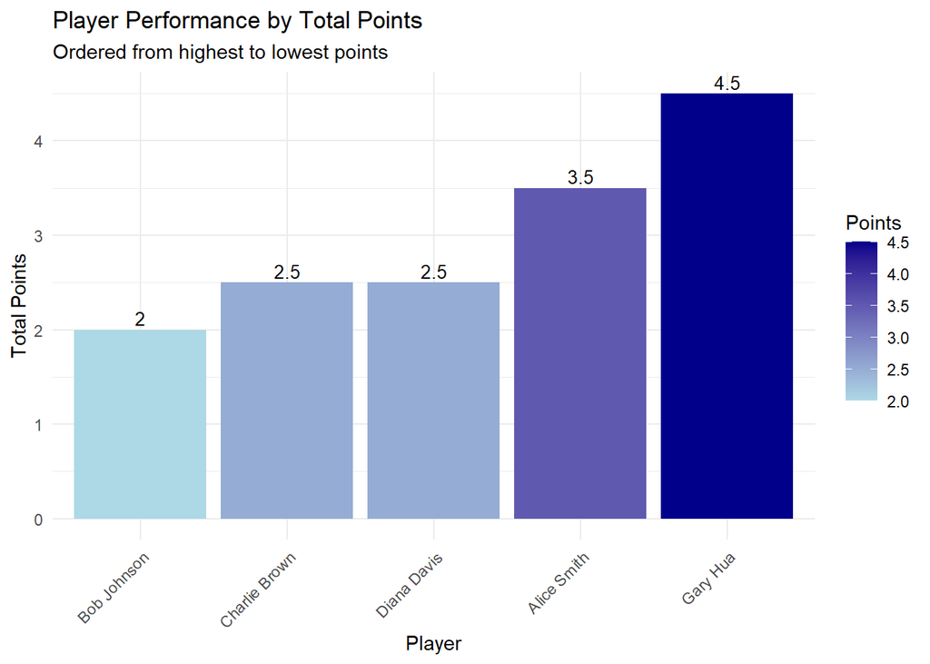

```r
# Read the data
player_data <- read.csv("player_stats_with_rounds_and_opponents.csv")

# Order players by total points (highest to lowest)
player_data_ordered <- player_data %>%
  arrange(desc(TotalPoints)) %>%
  mutate(Player = fct_reorder(Player, TotalPoints))

# Create the plot
ggplot(player_data_ordered, aes(x = Player, y = TotalPoints, fill = TotalPoints)) +
  geom_bar(stat = "identity") +
  scale_fill_gradient(low = "lightblue", high = "darkblue") +
  labs(title = "Player Performance by Total Points",
       subtitle = "Ordered from highest to lowest points",
       x = "Player",
       y = "Total Points",
       fill = "Points") +
  theme_minimal() +
  theme(axis.text.x = element_text(angle = 45, hjust = 1)) +
  geom_text(aes(label = TotalPoints), vjust = -0.3, size = 3.5)
```

### Plot Comparing Player Pre-Rating vs Average Opponent Rating

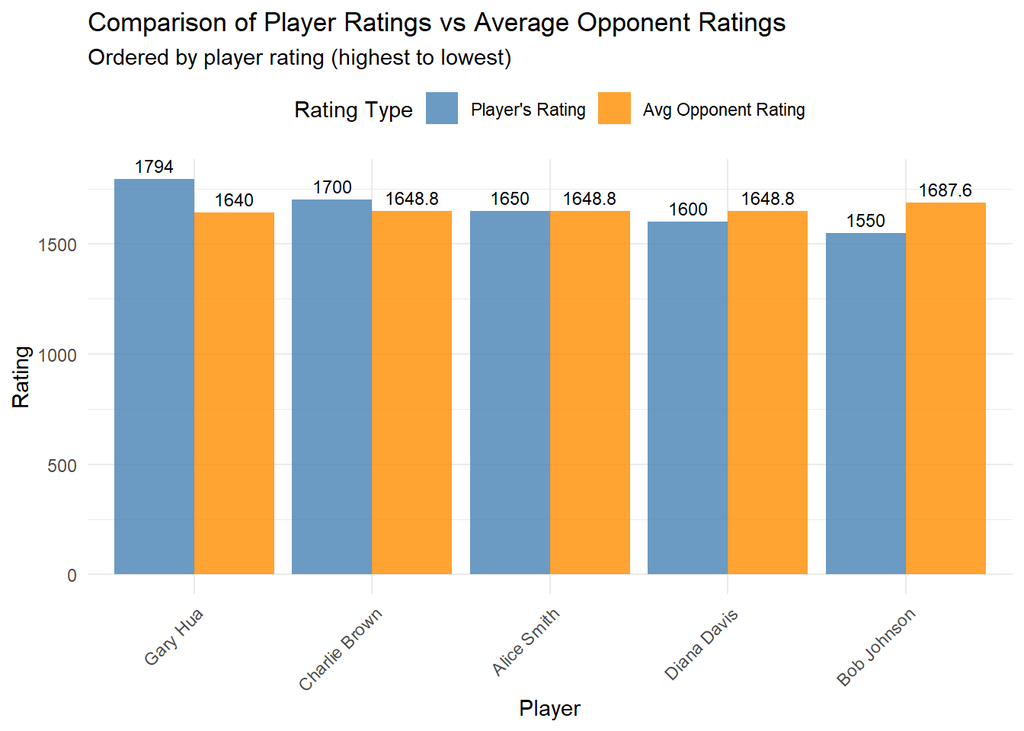

```r
# Read the data
player_data <- read.csv("player_stats_with_rounds_and_opponents.csv")

# Prepare data for plotting
rating_comparison <- player_data %>%
  select(Player, PreRating, AvgOpponentRating) %>%
  pivot_longer(cols = c(PreRating, AvgOpponentRating),
               names_to = "RatingType",
               values_to = "Rating") %>%
  mutate(RatingType = factor(RatingType,
                             levels = c("PreRating", "AvgOpponentRating"),
                             labels = c("Player's Rating", "Avg Opponent Rating")))

# Order players by their pre-rating (highest to lowest)
player_order <- player_data %>%
  arrange(desc(PreRating)) %>%
  pull(Player)

rating_comparison <- rating_comparison %>%
  mutate(Player = factor(Player, levels = player_order))

# Create the comparison plot
ggplot(rating_comparison, aes(x = Player, y = Rating, fill = RatingType)) +
  geom_bar(stat = "identity", position = "dodge", alpha = 0.8) +
  scale_fill_manual(values = c("Player's Rating" = "steelblue",
                               "Avg Opponent Rating" = "darkorange")) +
  labs(title = "Comparison of Player Ratings vs Average Opponent Ratings",
       subtitle = "Ordered by player rating (highest to lowest)",
       x = "Player",
       y = "Rating",
       fill = "Rating Type") +
  theme_minimal() +
  theme(axis.text.x = element_text(angle = 45, hjust = 1),
        legend.position = "top") +
  geom_text(aes(label = Rating, group = RatingType),
            position = position_dodge(width = 0.9),
            vjust = -0.5, size = 3)
```

### Rating vs Performance Insights

- Gary Hua: Highest pre-rating (1794) and highest tournament points - demonstrating expected dominance from the top-rated player
- Charlie Brown: Second-highest pre-rating (1700) but finished third in points - underperformed relative to rating expectations
- Alice Smith: Third-highest pre-rating (1650) but achieved second-highest points - exceeded expectations by outperforming higher-rated competitors

## Summary of Achievements in the CSV File

We have successfully created a comprehensive chess tournament data analysis CSV file that includes:

### Player Performance Metrics

- Player Identification: Name and state for each participant
- Skill Assessment: Pre-tournament rating for each player
- Performance Measurement: Total points calculated from round results

### Competition Quality:

- Average rating of opponents faced

#### Detailed Round-by-Round Analysis

- Results Tracking: Win (W), Loss (L), or Draw (D) for each of the 5 rounds
- Opponent Identification: Specific opponent faced in each round
- Complete Match History: Full record of all games played in the tournament